# Week 4 Lecture 1 Predictive Modeling

### Predicting Life Expectancy

Suppose we want to predict life expectancy from the GDP per capita. As we saw, it makes sense to draw a straight line through the log-log plot of `lifeExp` vs. `gdpPercap`:

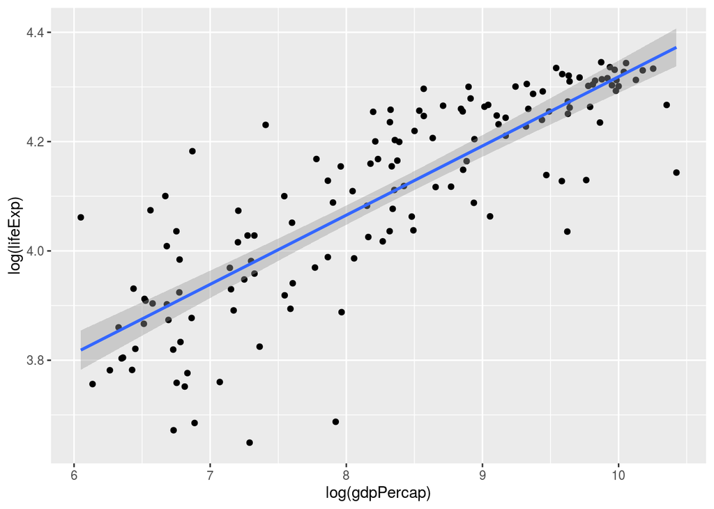

```r
gap.1982 <- gapminder %>% filter(year == 1982)
ggplot(gap.1982, mapping = aes(x = log(gdpPercap), y = log(lifeExp))) +
         geom_point() +
         geom_smooth(method = "lm")
```

Let’s now get the equation for the best line through the data:

```r
lm(log(lifeExp) ~ log(gdpPercap), data = gap.1982)
```

```
##
## Call:
## lm(formula = log(lifeExp) ~ log(gdpPercap), data = gap.1982)
##
## Coefficients:
##    (Intercept)  log(gdpPercap)
##         3.0527          0.1266
```

For example, for a country with a `gdpPercap` of $10,000, we would predict a `log(lifeExp)` of

```r
3.0527 + 0.1266 * log(10000)
```

```
## [1] 4.218729
```

The prediction for `lifeExp` will be

```r
exp(3.0527 + 0.1266 * log(10000))
```

```
## [1] 67.94707
```

We can get all the predictions using

```r
model <- lm(log(lifeExp) ~ log(gdpPercap), data = gap.1982)
predict(model, newdata = gap.1982)
```

```
##        1        2        3        4        5        6        7        8
## 3.924370 4.090434 4.148530 4.055575 4.205327 4.303094 4.316175 4.301354
##        9       10       11       12       13       14       15       16
## 3.877797 4.312504 3.958230 4.072709 4.106637 4.119034 4.174096 4.193944
##       17       18       19       20       21       22       23       24
## 3.900069 3.853690 3.867576 4.036320 4.323585 3.921588 3.898603 4.133341
##       25       26       27       28       29       30       31       32
## 3.922336 4.114688 3.957156 3.877190 4.127854 4.137426 4.048286 4.254053
##       33       34       35       36       37       38       39       40
## 4.179146 4.273172 4.316707 4.061079 4.060269 4.177349 4.085921 4.105767
##       41       42       43       44       45       46       47       48
## 3.917701 3.845579 3.857754 4.296805 4.308296 4.270981 3.904479 4.318697
##       49       50       51       52       53       54       55       56
## 3.910429 4.272273 4.126313 3.907685 3.904829 4.015643 4.071308 4.266263
##       57       58       59       60       61       62       63       64
## 4.247411 4.325618 3.907460 3.979934 4.184090 4.265892 4.248138 4.273088
##       65       66       67       68       69       70       71       72
## 4.282382 4.155452 4.302489 4.107700 3.965012 4.106019 4.145807 4.363370
##       73       74       75       76       77       78       79       80
## 4.184625 3.898501 3.856508 4.288558 3.960681 3.869253 4.128909 3.866259
##       81       82       83       84       85       86       87       88
## 3.976916 4.092412 4.213674 4.014977 4.233298 4.053055 3.829483 3.818558
##       89       90       91       92       93       94       95       96
## 4.108600 3.885310 4.315011 4.290498 4.084709 3.915207 3.984853 4.341110
##       97       98       99      100      101      102      103      104
## 4.251470 3.973651 4.173713 4.110620 4.162876 4.048313 4.197396 4.239154
##      105      106      107      108      109      110      111      112
## 4.222818 4.137534 4.213597 3.911227 4.007791 4.372479 3.980068 4.271547
##      113      114      115      116      117      118      119      120
## 3.975529 4.271448 4.234711 4.292169 3.947796 4.199133 4.260624 3.990436
##      121      122      123      124      125      126      127      128
## 4.008147 4.099337 4.310604 4.350832 4.094920 4.181025 3.910170 4.037662
##      129      130      131      132      133      134      135      136
## 3.964669 4.207027 4.087947 4.110109 3.878781 4.294734 4.334747 4.172089
##      137      138      139      140      141      142
## 4.232504 3.883331 4.112904 4.013510 3.970565 3.897159
```

```r
new.df <- data.frame(gdpPercap = 10000)
exp(predict(model, newdata = new.df))
```

```
##        1
## 67.94479
```

For `gap.1982`, we can compute the sum of squared errors as follows.

The errors (for predicting the log of the life expectancy) are

```r
log(gap.1982$lifeExp) - predict(model, newdata = gap.1982)
```

```
##             1             2             3             4             5
## -0.2391474617  0.1640429479 -0.0316409825 -0.3681464245  0.0423392656
##             6             7             8             9            10
##  0.0109212642 -0.0232528968 -0.0664942997  0.0344064543 -0.0093854207
##            11            12            13            14            15
## -0.0282882783 -0.0863396317  0.1516670917 -0.0002570061 -0.0256424823
##            16            17            18            19            20
##  0.0698617837 -0.0263294506  0.0064294423  0.0634064373 -0.0667645308
##            21            22            23            24            25
##  0.0039859385 -0.0442599971  0.0037127148  0.1231928040  0.2600958659
##            26            27            28            29            30
##  0.0848116405  0.0118714353 -0.0104994360 -0.0901677788  0.1591792155
##            31            32            33            34            35
## -0.0596168188  0.0009920808  0.1210877484 -0.0110559754 -0.0041645515
##            36            37            38            39            40
## -0.1731031731  0.0943394883 -0.0131360316 -0.0604625511 -0.0696871195
##            41            42            43            44            45
## -0.1412229925 -0.0638921785 -0.0529600006  0.0146645909  0.0077247358
##            46            47            48            49            50
## -0.2356082938 -0.0850095476 -0.0173377733  0.0738028924  0.0484096932
##            51            52            53            54            55
## -0.0635110584 -0.1490232630 -0.2329173400 -0.0748186425  0.0380732627
##            56            57            58            59            60
##  0.0572069207 -0.0076678732  0.0180573160  0.1284787210  0.0482533036
##            61            62            63            64            65
## -0.0960990271 -0.1381450173  0.0436899365  0.0370394452  0.0348398913
##            66            67            68            69            70
##  0.1101812227  0.0427441357  0.0470963456  0.1085512262  0.1295354874
##            71            72            73            74            75
##  0.0607195187 -0.0963475500  0.0198143188  0.1102494125 -0.0531394972
##            76            77            78            79            80
## -0.1589265546 -0.0694933321 -0.0484246413  0.0905984810 -0.0839802229
##            81            82            83            84            85
##  0.0046139283  0.1079580672 -0.0029550299  0.0366170135  0.0721309750
##            86            87            88            89            90
##  0.0354392614 -0.0730613960  0.2428496873 -0.0316052279  0.0185602210
##            91            92            93            94            95
##  0.0163797550  0.0114027629 -0.0021334696 -0.1633992567 -0.1600013429
##            96            97            98            99           100
## -0.0107717725 -0.1126621322  0.0545185769  0.0815020331  0.0921902415
##           101           102           103           104           105
## -0.0453679940  0.0801426793  0.0697804592  0.0481501974  0.0778630600
##           106           107           108           109           110
##  0.1093175104  0.0300288999 -0.0778576334  0.0923863513 -0.2291541708
##           111           112           113           114           115
## -0.0215619542 -0.0207402785 -0.3263007475  0.0018796267  0.0251479358
##           116           117           118           119           120
## -0.0286023034 -0.1876433381 -0.1359179980  0.0740490892  0.2401420691
##           121           122           123           124           125
## -0.0893871225 -0.0818550787  0.0256400488 -0.0173395343  0.0731394514
##           126           127           128           129           130
##  0.0978606743  0.0139394701  0.1305055461  0.0511911356  0.0246417919
##           131           132           133           134           135
##  0.0716860514  0.0013546448  0.0302175178  0.0098712168 -0.0219369264
##           136           137           138           139           140
##  0.0878408426 -0.0048383826  0.1910824288  0.0523026663 -0.1193859855
##           141           142
## -0.0227698185  0.2032176331
```

The sum of the squared errors is then

```r
sum((log(gap.1982$lifeExp) - predict(model, newdata = gap.1982))^2)
```

```
## [1] 1.484817
```

## Multiple linear regression

Let’s now use both the `log(gdpPercap)` and the year to predict the log of the life expectancy. We’ll use the full `gapminder` dataset – otherwise using the year doesn’t really make sense.

```r
model2 <- lm(log(lifeExp) ~ log(gdpPercap) + year, data = gapminder)
```

We’ll also define the old model that ignores the year:

```r
model1 <- lm(log(lifeExp) ~ log(gdpPercap), data = gapminder)
```

Let’s look at `model2`:

```r
model2
```

```
##
## Call:
## lm(formula = log(lifeExp) ~ log(gdpPercap) + year, data = gapminder)
##
## Coefficients:
##    (Intercept)  log(gdpPercap)            year
##      -4.054829        0.135050        0.003543
```

The implied equation is

$\log(\text{lifeExp}) \approx -4.054829 + 0.135050\log(\text{gdpPercap}) + 0.003543\text{year}$

What does that mean? Here’s an example.

How is the predictions of $\log(\text{lifeExp})$ are going to differ between 1980 and 1981, if the gdpPercap is still the same? The predictions would differ by $0.003543\times(1981-1980) = 0.003543$ (Why?).

#### An aside on $\log$

$\log(ab) = \log(a) + \log(b)$. This means that if $\log(b)$ increases by 2, $ab$ increases by a factor of $\exp(2)$.

In our case, if year increases by 1, $0.003543\text{year}$ increases by $0.003543$, so the predicted $\log(\text{lifeExp})$ increases by $0.003543$, so the predicted `lifeExp` increases by a factor of $\exp(0.003543)$ (i.e., the new prediction is $\exp(0.003543)$ times the old one).

### Which model would have the smaller sum of squared errors?

We can compare the two models:

```r
model1 <- lm(log(lifeExp) ~ log(gdpPercap), data = gapminder)
model2 <- lm(log(lifeExp) ~ log(gdpPercap) + year, data = gapminder)
sum((log(gapminder$lifeExp) - predict(model1, newdata = gapminder))^2)
```

```
## [1] 35.54009
```

```r
sum((log(gapminder$lifeExp) - predict(model2, newdata = gapminder))^2)
```

```
## [1] 29.51551
```

As we might expect, the sum of squared errors is larger for `model1` than for model2`.

### Predictions using categorical variables

Let’s predict the life expectancy using continent and the year:

```r
model3 <- lm(lifeExp ~ continent + year, data = gapminder)
model3
```

```
##
## Call:
## lm(formula = lifeExp ~ continent + year, data = gapminder)
##
## Coefficients:
##       (Intercept)  continentAmericas      continentAsia    continentEurope
##         -596.2613            15.7934            11.1996            23.0384
##  continentOceania               year
##           25.4609             0.3259
```

For Americas in 1980, the prediction will be `-596.2613 + 15.7934 + 1980*0.3259`. For Africa in 1990, the prediction will be `-596.2613 + 0.3259*1990` (Note that we don’t add a coefficient for Africa, since R chose to only use indicator variables for the other four continents).